# Project: Investigate a Dataset - TMDb movie data

By Henrik Rodahl Dokset

- Introduction
- Data Wrangling
- Exploratory Data Analysis
- Conclusions

## Introduction

### Dataset Description

This data set contains information about 10,000 movies collected from The Movie Database (TMDb), including user ratings and revenue. Certain columns, like ‘cast’ and ‘genres’, contain multiple values separated by pipe (|) characters. There are some odd characters in the ‘cast’ column. The final two columns ending with “_adj” show the budget and revenue of the associated movie in terms of 2010 dollars, accounting for inflation over time. We will during evaluation of the data look at statistics such as mean, min and max values for the columns to understand the data.

### Question(s) for Analysis

In this data analysis report, we will primarily focus our attention around the movie ratings and how those ratings relate to other variables. The report will be limited to aggregations and descriptive statistical graphs, and not dwelve into inferential statistics or machine learning concepts. We will look to answer the following two research questions:

- How does genres relate to ratings? Are certain genres generally rated better?
- Does it matter for the rating who is directing the movie and who the protagonist is?

```python
# Libraries #
import pandas as pd
import numpy as np
import matplotlib.pyplot as plt
```

## Data Wrangling

> In this section we will inspect the data for its properties and qualities before we decide the next steps for cleaning and analysis.

```python
# Load Data #
df = pd.read_csv('Database_TMDb_movie_data/tmdb-movies.csv')
```

```python
# Inspect the data #
df.head(3)
```

|  | id | imdb_id | popularity | budget | revenue | original_title | cast | homepage | director | tagline | ... | overview | runtime | genres | production_companies | release_date | vote_count | vote_average | release_year | budget_adj | revenue_adj |
| --- | --- | --- | --- | --- | --- | --- | --- | --- | --- | --- | --- | --- | --- | --- | --- | --- | --- | --- | --- | --- | --- |
| 0 | 135397 | tt0369610 | 32.985763 | 150000000 | 1513528810 | Jurassic World | Chris Pratt\|Bryce Dallas Howard\|Irrfan Khan\|Vi... | http://www.jurassicworld.com/ | Colin Trevorrow | The park is open. | ... | Twenty-two years after the events of Jurassic ... | 124 | Action\|Adventure\|Science Fiction\|Thriller | Universal Studios\|Amblin Entertainment\|Legenda... | 6/9/15 | 5562 | 6.5 | 2015 | 1.379999e+08 | 1.392446e+09 |
| 1 | 76341 | tt1392190 | 28.419936 | 150000000 | 378436354 | Mad Max: Fury Road | Tom Hardy\|Charlize Theron\|Hugh Keays-Byrne\|Nic... | http://www.madmaxmovie.com/ | George Miller | What a Lovely Day. | ... | An apocalyptic story set in the furthest reach... | 120 | Action\|Adventure\|Science Fiction\|Thriller | Village Roadshow Pictures\|Kennedy Miller Produ... | 5/13/15 | 6185 | 7.1 | 2015 | 1.379999e+08 | 3.481613e+08 |
| 2 | 262500 | tt2908446 | 13.112507 | 110000000 | 295238201 | Insurgent | Shailene Woodley\|Theo James\|Kate Winslet\|Ansel... | http://www.thedivergentseries.movie/#insurgent | Robert Schwentke | One Choice Can Destroy You | ... | Beatrice Prior must confront her inner demons ... | 119 | Adventure\|Science Fiction\|Thriller | Summit Entertainment\|Mandeville Films\|Red Wago... | 3/18/15 | 2480 | 6.3 | 2015 | 1.012000e+08 | 2.716190e+08 |

3 rows × 21 columns

```python
# Inspect the uniques for each column
df.nunique()
```

```
id                      10865
imdb_id                 10855
popularity              10814
budget                    557
revenue                  4702
original_title          10571
cast                    10719
homepage                 2896
director                 5067
tagline                  7997
keywords                 8804
overview                10847
runtime                   247
genres                   2039
production_companies     7445
release_date             5909
vote_count               1289
vote_average               72
release_year               56
budget_adj               2614
revenue_adj              4840
dtype: int64
```

By inspecting the dataframe we get an initial impression for the columns contents. Certain columns of special interest include budget, title, cast, director, runtime, genres, production_companies, vote_average and vote_count. On first look the data seems to be of quality, but we need to have a closer look.

The headers are all in lowercase with no spaces inbetween words, which is good. In terms of unique values it may be odd that continuous variables such as budget, revenue etc dont have more uniques. There are 1289 unique vote counts and 72 unique vote averages. There are also 2039 genres, which is simply too many to do any sort of categorical analysis. We can see from the previous `df.head(3)` that each genre is a combination of genres. We will consider a cleaning decision here as well.

```python
df.describe()
```

|  | id | popularity | budget | revenue | runtime | vote_count | vote_average | release_year | budget_adj | revenue_adj |
| --- | --- | --- | --- | --- | --- | --- | --- | --- | --- | --- |
| count | 10866.000000 | 10866.000000 | 1.086600e+04 | 1.086600e+04 | 10866.000000 | 10866.000000 | 10866.000000 | 10866.000000 | 1.086600e+04 | 1.086600e+04 |
| mean | 66064.177434 | 0.646441 | 1.462570e+07 | 3.982332e+07 | 102.070863 | 217.389748 | 5.974922 | 2001.322658 | 1.755104e+07 | 5.136436e+07 |
| std | 92130.136561 | 1.000185 | 3.091321e+07 | 1.170035e+08 | 31.381405 | 575.619058 | 0.935142 | 12.812941 | 3.430616e+07 | 1.446325e+08 |
| min | 5.000000 | 0.000065 | 0.000000e+00 | 0.000000e+00 | 0.000000 | 10.000000 | 1.500000 | 1960.000000 | 0.000000e+00 | 0.000000e+00 |
| 25% | 10596.250000 | 0.207583 | 0.000000e+00 | 0.000000e+00 | 90.000000 | 17.000000 | 5.400000 | 1995.000000 | 0.000000e+00 | 0.000000e+00 |
| 50% | 20669.000000 | 0.383856 | 0.000000e+00 | 0.000000e+00 | 99.000000 | 38.000000 | 6.000000 | 2006.000000 | 0.000000e+00 | 0.000000e+00 |
| 75% | 75610.000000 | 0.713817 | 1.500000e+07 | 2.400000e+07 | 111.000000 | 145.750000 | 6.600000 | 2011.000000 | 2.085325e+07 | 3.369710e+07 |
| max | 417859.000000 | 32.985763 | 4.250000e+08 | 2.781506e+09 | 900.000000 | 9767.000000 | 9.200000 | 2015.000000 | 4.250000e+08 | 2.827124e+09 |

Our independent variable is `vote_average`. From `df.describe`we find the min vote count of 10, and the vote count quantiles 25% = 17 and 50% = 38. These vote counts are quite low from a statistical point of view. We should set a minimum threshold for data quality purposes.

```python
df.info()
```

```
<class 'pandas.core.frame.DataFrame'>
RangeIndex: 10866 entries, 0 to 10865
Data columns (total 21 columns):
 #   Column                Non-Null Count  Dtype
---  ------                --------------  -----
 0   id                    10866 non-null  int64
 1   imdb_id               10856 non-null  object
 2   popularity            10866 non-null  float64
 3   budget                10866 non-null  int64
 4   revenue               10866 non-null  int64
 5   original_title        10866 non-null  object
 6   cast                  10790 non-null  object
 7   homepage              2936 non-null   object
 8   director              10822 non-null  object
 9   tagline               8042 non-null   object
 10  keywords              9373 non-null   object
 11  overview              10862 non-null  object
 12  runtime               10866 non-null  int64
 13  genres                10843 non-null  object
 14  production_companies  9836 non-null   object
 15  release_date          10866 non-null  object
 16  vote_count            10866 non-null  int64
 17  vote_average          10866 non-null  float64
 18  release_year          10866 non-null  int64
 19  budget_adj            10866 non-null  float64
 20  revenue_adj           10866 non-null  float64
dtypes: float64(4), int64(6), object(11)
memory usage: 1.7+ MB
```

```python
# Compute a NA table to see how many NAs exist for each column
df.isna().sum().sort_values(ascending=False)
```

```
homepage                7930
tagline                 2824
keywords                1493
production_companies    1030
cast                      76
director                  44
genres                    23
imdb_id                   10
overview                   4
budget_adj                 0
release_year               0
vote_average               0
vote_count                 0
release_date               0
id                         0
runtime                    0
original_title             0
revenue                    0
budget                     0
popularity                 0
revenue_adj                0
dtype: int64
```

By inspecting the result from `df.info` and the NA table, we get a general idea for the data quality. Certain columns have too many NAs and will be removed. This includes homepage, tagline and keywords. Production_companies could be interesting for our analysis, but we decide to drop it this time because of it containing over 1000 NAs.

Our columns of interest looks to be of general good quality, but cast, director and genres contain some NA-rows which we will drop from the dataframe in the next section. Imputation could also be an option, but in this case as we are mostly interested in creating descriptive statistics for our independent variable vote_average, and NAs would simply cause noise.

When it comes to incorrect data types, we don't spot any of those at the moment. Duplicates will be inspected below.

```python
df.duplicated().sum()
```

```
1
```

```python
ids = df.id
df[ids.isin(ids[df.duplicated()])]
```

|  | id | imdb_id | popularity | budget | revenue | original_title | cast | homepage | director | tagline | ... | overview | runtime | genres | production_companies | release_date | vote_count | vote_average | release_year | budget_adj | revenue_adj |
| --- | --- | --- | --- | --- | --- | --- | --- | --- | --- | --- | --- | --- | --- | --- | --- | --- | --- | --- | --- | --- | --- |
| 2089 | 42194 | tt0411951 | 0.59643 | 30000000 | 967000 | TEKKEN | Jon Foo\|Kelly Overton\|Cary-Hiroyuki Tagawa\|Ian... | NaN | Dwight H. Little | Survival is no game | ... | In the year of 2039, after World Wars destroy ... | 92 | Crime\|Drama\|Action\|Thriller\|Science Fiction | Namco\|Light Song Films | 3/20/10 | 110 | 5.0 | 2010 | 30000000.0 | 967000.0 |
| 2090 | 42194 | tt0411951 | 0.59643 | 30000000 | 967000 | TEKKEN | Jon Foo\|Kelly Overton\|Cary-Hiroyuki Tagawa\|Ian... | NaN | Dwight H. Little | Survival is no game | ... | In the year of 2039, after World Wars destroy ... | 92 | Crime\|Drama\|Action\|Thriller\|Science Fiction | Namco\|Light Song Films | 3/20/10 | 110 | 5.0 | 2010 | 30000000.0 | 967000.0 |

2 rows × 21 columns

There is 1 duplicate in our dataframe which will be removed in the data cleaning section.

## Data Cleaning

In this section I will perform the data cleaning steps described in the previous section as well as additional steps. This includes:

1. Removing duplicates
2. Remove columns with NAs
3. Remove rows with remaining NAs
4. Remove rows with too few vote rates for analysis
5. Adjusting columns with pipe characters such as cast, director and genres

```python
df.shape
```

```
(10866, 21)
```

```python
df.drop_duplicates(inplace=True)
df.shape
```

```
(10865, 21)
```

Before removing the duplicate, we inspect the dataframe with `df.shape`. The duplicate is then removed and we confirm our dataframe is changed.

```python
df.isna().sum().sort_values(ascending=False)
```

```
homepage                7929
tagline                 2824
keywords                1493
production_companies    1030
cast                      76
director                  44
genres                    23
imdb_id                   10
overview                   4
budget_adj                 0
release_year               0
vote_average               0
vote_count                 0
release_date               0
id                         0
runtime                    0
original_title             0
revenue                    0
budget                     0
popularity                 0
revenue_adj                0
dtype: int64
```

```python
# Drop columns with too many NA values
df.drop(['homepage', 'tagline', 'keywords', 'production_companies'], axis=1, inplace=True)
```

```python
# Drop any remaining row with NA values and confirm our data are to expectations
df = df.dropna()
df.isna().sum().sort_values(ascending=False)
```

```
id                0
runtime           0
budget_adj        0
release_year      0
vote_average      0
vote_count        0
release_date      0
genres            0
overview          0
imdb_id           0
director          0
cast              0
original_title    0
revenue           0
budget            0
popularity        0
revenue_adj       0
dtype: int64
```

```python
df.shape
```

```
(10724, 17)
```

**Takeaway**: We remove the 4 columns with a lot of NAs, then remove any remaining rows with NAs. Dataframe went from shape 10865,21 to shape 10724,17

#### Removing rows with a low vote count

A high vote count is preferred when analysing movie ratings as a low vote count can be more prone to bias. For example, say 15 students from a school class went to a cinema together, afterwards everyone rated the movie. Then, each view is likely to be influenced by the others in the group. The students in the class are also of the same age, and the culture may be the same. This is sample bias, and we are not looking at a random sample in this case. In IMDB, this phenomenon is typically seen right after movie releases. You will have few movie votes in the beginning, and then usually as the movie gets more reviews, the rating can stabilize at a lower level than what it was. Preferably we would like a rate count of say, at least 10.000, but in this dataset we will need to settle with less. We will first inspect the quantiles first, then decide on a threshold.

```python
df['vote_count'].describe()
```

```
count    10724.000000
mean       219.943305
std        578.981655
min         10.000000
25%         17.000000
50%         39.000000
75%        148.250000
max       9767.000000
Name: vote_count, dtype: float64
```

50% of the data falls below a vote count of 39. The trade-off here is that we need to remove movies with too few votes (as our independent variable is dependent on the number of votes), and still retain enough data for analysis. Removing 50% of the data is already quite a lot, so we decide this as our threshold.

```python
# We remove the rows with fewer than 39 votes, and confirm changes to the dataframe
df = df.query('vote_count > 39')
df['vote_count'].describe()
```

```
count    5324.000000
mean      423.490421
std       770.018087
min        40.000000
25%        70.000000
50%       151.000000
75%       402.000000
max      9767.000000
Name: vote_count, dtype: float64
```

After the vote count threshold was set above 39 (the 50% percentile), our adjusted dataset have more than 75% of its data above a vote count of 70 (the 25% quantile).

#### Cast adjustment

The cast consists of multiple actors. As we are only interested in the main protagonist, we will extract that from this column and create a new column. It doesnt actually say anywhere in the dataset documentation that the protagonist is the first actor, but this is what should be the case. The most important actor comes first, and it is also the way IMDB is set up. We will confirm the result by inspecting the top 20 rated movies.

```python
# Perform the string split and confirm the | with the remaining cast is removed
df['protagonist'] = df['cast'].str.split("|").str.get(0)
df.protagonist.head()
```

```
0         Chris Pratt
1           Tom Hardy
2    Shailene Woodley
3       Harrison Ford
4          Vin Diesel
Name: protagonist, dtype: object
```

```python
df[['protagonist', 'original_title', 'vote_average']].sort_values(by='vote_average', ascending=False).head(n=20)
```

|  | protagonist | original_title | vote_average |
| --- | --- | --- | --- |
| 1200 | Jon Hamm | Black Mirror: White Christmas | 8.8 |
| 3690 | Travis Rice | The Art of Flight | 8.5 |
| 4178 | Tim Robbins | The Shawshank Redemption | 8.4 |
| 609 | Robert Durst | The Jinx: The Life and Deaths of Robert Durst | 8.4 |
| 7269 | Marlon Brando | The Godfather | 8.3 |
| 3310 | Kurt Kuenne | Dear Zachary: A Letter to a Son About His Father | 8.3 |
| 650 | Miles Teller | Whiplash | 8.2 |
| 611 | Julia Pott | World of Tomorrow | 8.2 |
| 10222 | Liam Neeson | Schindler's List | 8.1 |
| 9758 | Al Pacino | The Godfather: Part II | 8.1 |
| 4177 | John Travolta | Pulp Fiction | 8.1 |
| 5827 | Alejandro Jodorowsky | Jodorowsky's Dune | 8.1 |
| 4179 | Tom Hanks | Forrest Gump | 8.1 |
| 2875 | Christian Bale | The Dark Knight | 8.1 |
| 2409 | Edward Norton | Fight Club | 8.1 |
| 736 | Brendan Gleeson | Song of the Sea | 8.0 |
| 2414 | Tom Hanks | The Green Mile | 8.0 |
| 8069 | Stephen Baldwin | The Usual Suspects | 8.0 |
| 4434 | John Kahrs | Paperman | 8.0 |
| 826 | Tommy Snider | Feast | 8.0 |

By inspecting the list, we find our intuition to generally be correct. The main character is filtered for as the protagonist. Certain movies however may have up to multiple protagonists, such as is the case for the Star Wars, but this phenomenon is not that prevalent and it does not affect our decision. A more quality assured way to perform this step would be to match information in a web site, or the first actor in the cast being confirmed in the dataset documentation. Let's take a look at the genres next.

```python
df.genres.nunique()
```

```
1350
```

```python
df.genres.head(1)
```

```
0    Action|Adventure|Science Fiction|Thriller
Name: genres, dtype: object
```

```python
# String split genres and confirm change
df['genre'] = df['genres'].str.split("|").str.get(0)
df.genre.head(5)
```

```
0       Action
1       Action
2    Adventure
3       Action
4       Action
Name: genre, dtype: object
```

```python
df.genre.nunique()
```

```
20
```

There are too many unique genres to perform any sort of categorical analysis. Most movies are a combinations of genres, but will have one main describing one. Hence, we use the same intuition here in that the first genre should be the one we are looking to filter for. We confirm our inuition by inspecting some action movies below.

```python
df.query('genre =="Action"')[['original_title', 'genre']].head(n=10)
```

|  | original_title | genre |
| --- | --- | --- |
| 0 | Jurassic World | Action |
| 1 | Mad Max: Fury Road | Action |
| 3 | Star Wars: The Force Awakens | Action |
| 4 | Furious 7 | Action |
| 10 | Spectre | Action |
| 13 | Pixels | Action |
| 14 | Avengers: Age of Ultron | Action |
| 20 | Tomorrowland | Action |
| 21 | Southpaw | Action |
| 22 | San Andreas | Action |

**Takeaway**: Most of these are action movies, but we do spot some combinations such as Jurassic World and Star Wars. However, the action tag is not wrong on those movies either and we consider the cleaning step successful. We perform the same cleaning step on directors, just in case.

```python
# Director cleaning
df['director'] = df['director'].str.split("|").str.get(0)
df.query('genre =="Action"')[['original_title', 'director']].head(n=10)
```

|  | original_title | director |
| --- | --- | --- |
| 0 | Jurassic World | Colin Trevorrow |
| 1 | Mad Max: Fury Road | George Miller |
| 3 | Star Wars: The Force Awakens | J.J. Abrams |
| 4 | Furious 7 | James Wan |
| 10 | Spectre | Sam Mendes |
| 13 | Pixels | Chris Columbus |
| 14 | Avengers: Age of Ultron | Joss Whedon |
| 20 | Tomorrowland | Brad Bird |
| 21 | Southpaw | Antoine Fuqua |
| 22 | San Andreas | Brad Peyton |

**Takeaway**: Result is to expectations.

## Exploratory Data Analysis

## Research Question 1 - How does genres relate to ratings? Are certain genres generally rated better?

We will start off by taking a closer look at statistics and the data in general, as well as our independent variable `vote_average`, before we start inspecting the relationship between our variables.

```python
df.head(1)
```

|  | id | imdb_id | popularity | budget | revenue | original_title | cast | director | overview | runtime | genres | release_date | vote_count | vote_average | release_year | budget_adj | revenue_adj | protagonist | genre |
| --- | --- | --- | --- | --- | --- | --- | --- | --- | --- | --- | --- | --- | --- | --- | --- | --- | --- | --- | --- |
| 0 | 135397 | tt0369610 | 32.985763 | 150000000 | 1513528810 | Jurassic World | Chris Pratt\|Bryce Dallas Howard\|Irrfan Khan\|Vi... | Colin Trevorrow | Twenty-two years after the events of Jurassic ... | 124 | Action\|Adventure\|Science Fiction\|Thriller | 6/9/15 | 5562 | 6.5 | 2015 | 1.379999e+08 | 1.392446e+09 | Chris Pratt | Action |

```python
df['vote_average'].describe()
```

```
count    5324.000000
mean        6.185481
std         0.799470
min         2.900000
25%         5.700000
50%         6.200000
75%         6.700000
max         8.800000
Name: vote_average, dtype: float64
```

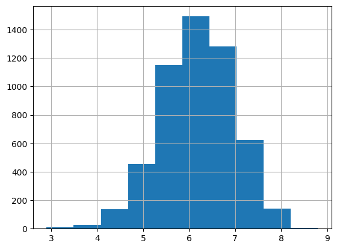

```python
df['vote_average'].hist();
```

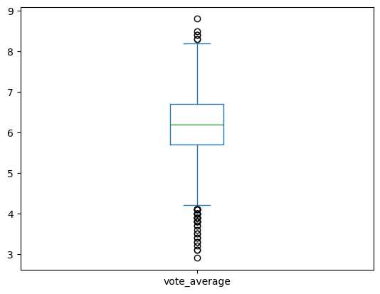

```python
df.plot(kind='box', y='vote_average');
```

Our independent variable `vote_average` has a min of 2.9, a max of 8.8 and a mean of 6.1854. From the histogram we observe an almost normal distribution, but there are outliers on both ends, and it is slightly skewed to the left. Scores between 3 and 4 fall outside the lower whisker, while scores above ~8.1 falls above the upper whisker. It seems more common for movies to receieve really bad scores (Vote averages <4) than to receieve exceptionally good scores (8.2+) in our dataframe. This is also confirmed in our boxplot, with many outliers spotted outside our lower whisker. The majority of the movie rating scores fall in the range of 5 to 8, centered between 5.5 and 7. Let's dig deeper into our research question next about genre.

### Digging deeper into Genre EDA

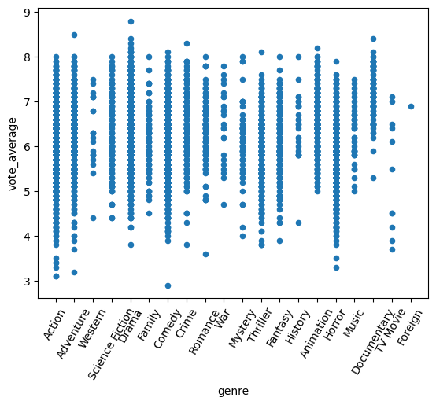

```python
# We start off by computing a scatterplot with our genres and their corresponding vote_averages
df.plot(kind='scatter', y='vote_average', x='genre', rot=60);
```

```python
genrestats = df.groupby(by='genre').mean(numeric_only=True)
genrestats
```

| genre | id | popularity | budget | revenue | runtime | vote_count | vote_average | release_year | budget_adj | revenue_adj |
| --- | --- | --- | --- | --- | --- | --- | --- | --- | --- | --- |
| Action | 42899.555152 | 1.326408 | 4.364539e+07 | 1.145840e+08 | 109.060606 | 635.021818 | 6.003030 | 2001.419394 | 5.084486e+07 | 1.366303e+08 |
| Adventure | 36757.051980 | 1.638500 | 5.677233e+07 | 1.798786e+08 | 109.769802 | 797.029703 | 6.219554 | 1999.643564 | 6.718378e+07 | 2.389361e+08 |
| Animation | 56501.537118 | 1.196063 | 3.611365e+07 | 1.253199e+08 | 71.982533 | 482.960699 | 6.542358 | 2004.755459 | 3.853314e+07 | 1.343926e+08 |
| Comedy | 48126.169929 | 0.840061 | 1.867114e+07 | 5.724974e+07 | 100.233096 | 272.572954 | 6.049644 | 2002.227758 | 2.203444e+07 | 7.381011e+07 |
| Crime | 48623.229665 | 1.034100 | 2.136806e+07 | 5.861904e+07 | 110.980861 | 397.387560 | 6.439713 | 2000.779904 | 2.573233e+07 | 8.057561e+07 |
| Documentary | 123937.329412 | 0.321622 | 1.515390e+06 | 8.766781e+06 | 103.729412 | 97.258824 | 7.181176 | 2009.541176 | 1.617613e+06 | 9.517437e+06 |
| Drama | 60189.590592 | 0.879977 | 1.857947e+07 | 5.117446e+07 | 115.071429 | 331.691638 | 6.472822 | 2003.272648 | 2.297623e+07 | 7.155838e+07 |
| Family | 75427.318841 | 1.182826 | 3.619388e+07 | 1.275459e+08 | 87.434783 | 429.188406 | 6.130435 | 2001.971014 | 4.015588e+07 | 1.601626e+08 |
| Fantasy | 37282.217687 | 1.355979 | 4.082789e+07 | 1.229373e+08 | 102.401361 | 566.707483 | 6.061224 | 2001.000000 | 4.680637e+07 | 1.499362e+08 |
| Foreign | 7452.000000 | 0.480761 | 0.000000e+00 | 0.000000e+00 | 125.000000 | 66.000000 | 6.900000 | 1989.000000 | 0.000000e+00 | 0.000000e+00 |
| History | 142811.360000 | 1.158689 | 2.225940e+07 | 7.747413e+07 | 121.160000 | 419.360000 | 6.464000 | 2006.040000 | 3.143357e+07 | 1.142022e+08 |
| Horror | 69746.246377 | 0.743027 | 1.088241e+07 | 3.657802e+07 | 96.775362 | 247.028986 | 5.714734 | 2002.306763 | 1.360464e+07 | 5.213769e+07 |
| Music | 78305.358974 | 0.810068 | 2.379487e+07 | 5.523573e+07 | 105.051282 | 212.358974 | 6.300000 | 2003.435897 | 2.916585e+07 | 8.448439e+07 |
| Mystery | 71230.355932 | 1.006532 | 1.900381e+07 | 4.798626e+07 | 104.593220 | 314.847458 | 6.113559 | 2001.847458 | 2.273291e+07 | 5.795787e+07 |
| Romance | 97508.040404 | 1.103890 | 1.892632e+07 | 6.861351e+07 | 107.757576 | 393.090909 | 6.346465 | 2004.737374 | 2.138381e+07 | 8.382886e+07 |
| Science Fiction | 62100.800000 | 1.728439 | 4.372702e+07 | 1.414370e+08 | 104.800000 | 898.191667 | 6.247500 | 2001.750000 | 5.175925e+07 | 1.764838e+08 |
| TV Movie | 175414.363636 | 0.429719 | 9.090909e+04 | 0.000000e+00 | 83.636364 | 92.636364 | 5.400000 | 2012.272727 | 8.509394e+04 | 0.000000e+00 |
| Thriller | 105513.904412 | 0.982698 | 2.103683e+07 | 4.724476e+07 | 105.981618 | 358.305147 | 5.911029 | 2006.805147 | 2.350628e+07 | 5.464107e+07 |
| War | 78169.217391 | 1.518186 | 5.448696e+07 | 1.161850e+08 | 151.000000 | 634.086957 | 6.460870 | 2004.304348 | 5.852475e+07 | 1.200947e+08 |
| Western | 73516.000000 | 1.067250 | 3.442857e+07 | 5.787488e+07 | 116.142857 | 349.428571 | 6.314286 | 1997.095238 | 3.945052e+07 | 6.898061e+07 |

**Takeaways**: From the scatterplot, we observe vote averages across the scale from ~3 all the way up to ~9. Most genres have scores spread out like the genre "Action", while others are more centered within a specific range such as "Documentary".

The descriptive statistics for the genres provide us with additional details, such as average runtime, average vote_count, average vote_average, average release_year, budget, and so on. The average runtime for animation movies are 72 minutes, while wartime movies are more than twice that length of 151, on average. Next, we can already now spot differences in vote averages across the genres, some with values below 6, others above 7. We will take a look at this next, but before that, let's make sure we have enough observations for each genre to draw any sort of average insight.

```python
df.genre.value_counts().sort_values(ascending=False)
```

```
Drama              1148
Comedy             1124
Action              825
Horror              414
Adventure           404
Thriller            272
Animation           229
Crime               209
Fantasy             147
Science Fiction     120
Romance              99
Documentary          85
Family               69
Mystery              59
Music                39
History              25
War                  23
Western              21
TV Movie             11
Foreign               1
Name: genre, dtype: int64
```

```python
# Removing the Genre "Foreign" from the dataframe
genrestats = genrestats.query('genre != "Foreign"')
df = df.query('genre != "Foreign"')
```

Except Foreign, there is generally enough movies to actually compare genres to the population mean in this sample. We remove foreign as it has only 1 observation, and continue our analysis.

```python
print(genrestats.vote_average.mean(), df.vote_average.mean())
```

```
6.23012636240949 6.185346609055044
```

To compare genres, we will use the sample mean `df.vote_average.mean()` to decide whether any genres perform well, or not so well.

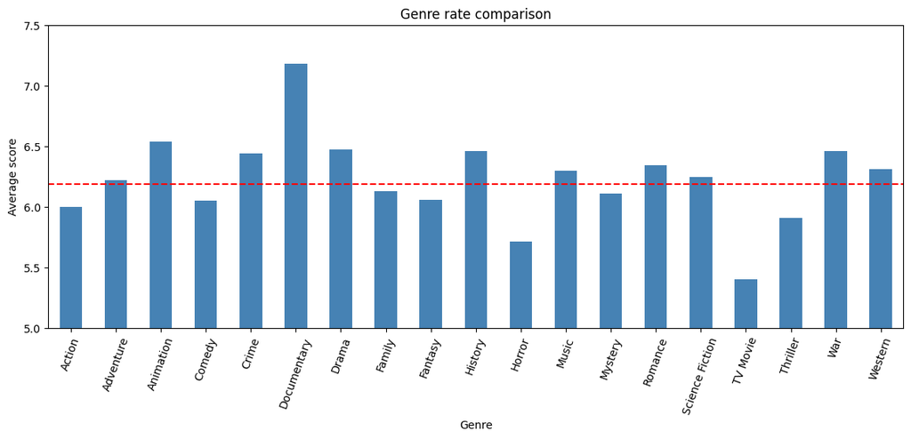

```python
ax = genrestats.plot(
    kind = 'bar'
    , y = 'vote_average'
    , ylim = [5,7.5]
    , title = 'Genre rate comparison'
    , ylabel = 'Average score'
    , xlabel = 'Genre'
    , legend = False
    , rot = 70
    , figsize = [14,5]
    , color = 'steelblue'
    )

ax.axhline(df.vote_average.mean(), color='red', linestyle='--')
ax.annotate('Av. Rating', xy=(19.5,df.vote_average.mean()), color='red')
plt.show()
```

From the graph we can observe how most genres fall within a rating average of approximately ~6.0 and ~6.5. However, some genres score noticably higher than the sample average. This includes for example animation and documentary. On the other hand, certain genres underperform on average. This includes the Horror genre and the TV Movie genre. Before we started this statistic we had a feeling horror would score low on average, and the graph confirms our expectation. However, this does not mean every horror movie is bad (receieves a low rating). For interest sake, let's look at some well performing horror movies.

```python
df.query('genre == "Horror"')[['original_title', 'vote_average']].sort_values(by='vote_average', ascending=False).head(n=5)
```

|  | original_title | vote_average |
| --- | --- | --- |
| 7310 | The Shining | 7.9 |
| 7825 | Alien | 7.6 |
| 10472 | Aliens | 7.6 |
| 9988 | Misery | 7.5 |
| 9600 | Evil Dead II | 7.5 |

Doing a top 5 scoring horror movies from the sample, we find the legendary "The Shining".

Let's continue our analysis by taking a closer look at how genres perform against the average rating score. We will compute statistics for min, max and quantiles in this next step in a graph and a table to compare the genres score-performance.

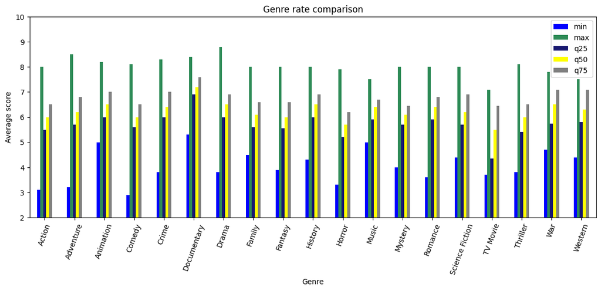

| genre | Action | Adventure | Animation | Comedy | Crime | Documentary | Drama | Family | Fantasy | History | Horror | Music | Mystery | Romance | Science Fiction | TV Movie | Thriller | War | Western |
| --- | --- | --- | --- | --- | --- | --- | --- | --- | --- | --- | --- | --- | --- | --- | --- | --- | --- | --- | --- |
| min | 3.1 | 3.2 | 5.0 | 2.9 | 3.8 | 5.3 | 3.8 | 4.5 | 3.90 | 4.3 | 3.3 | 5.0 | 4.00 | 3.6 | 4.4 | 3.70 | 3.8 | 4.70 | 4.4 |
| max | 8.0 | 8.5 | 8.2 | 8.1 | 8.3 | 8.4 | 8.8 | 8.0 | 8.00 | 8.0 | 7.9 | 7.5 | 8.00 | 8.0 | 8.0 | 7.10 | 8.1 | 7.80 | 7.5 |
| q25 | 5.5 | 5.7 | 6.0 | 5.6 | 6.0 | 6.9 | 6.0 | 5.6 | 5.55 | 6.0 | 5.2 | 5.9 | 5.70 | 5.9 | 5.7 | 4.35 | 5.4 | 5.75 | 5.8 |
| q50 | 6.0 | 6.2 | 6.5 | 6.0 | 6.4 | 7.2 | 6.5 | 6.1 | 6.00 | 6.5 | 5.7 | 6.4 | 6.10 | 6.4 | 6.2 | 5.50 | 6.0 | 6.50 | 6.3 |
| q75 | 6.5 | 6.8 | 7.0 | 6.5 | 7.0 | 7.6 | 6.9 | 6.6 | 6.60 | 6.9 | 6.2 | 6.7 | 6.45 | 6.8 | 6.9 | 6.45 | 6.5 | 7.10 | 7.1 |

```python
sum_stats = df.groupby('genre')['vote_average'].agg([
    'min', 'max', lambda x: x.quantile(0.25), lambda x: x.quantile(0.5), lambda x: x.quantile(0.75)])
sum_stats = sum_stats.rename(columns={'<lambda_0>': 'q25', '<lambda_1>': 'q50', '<lambda_2>': 'q75'})
ax = sum_stats.plot(kind='bar'
    , ylim = [2,10]
    , title = 'Genre rate comparison'
    , ylabel = 'Average score'
    , xlabel = 'Genre'
    , legend = 'upper right'
    , rot = 70
    , figsize = [14,5]
    , color = ['blue', 'seagreen', 'midnightblue', 'yellow', 'grey']
)
plt.show()
sum_stats.transpose()
```

Next, we will compute a timeseries for the different genres over time to see if we can spot anything interesting for our analysis.

```python
# First let's have a look at which genres actually have enough data for a 55 year timeseries
df['genre'].value_counts().head(15)
```

```
Drama              1148
Comedy             1124
Action              825
Horror              414
Adventure           404
Thriller            272
Animation           229
Crime               209
Fantasy             147
Science Fiction     120
Romance              99
Documentary          85
Family               69
Mystery              59
Music                39
Name: genre, dtype: int64
```

For a 55 year timeseries (1960-2015) a couple hundred rows of data is our minimum requirement to avoid missing datapoints, or too many "one-datapoint cases" per year. We also need to think about data readability. Too many genres in one plot will cause confusion and poor readability, so let's stick with comparing a couple of the genres and how they perform in terms of average vote score.

```python
def genre_timeplot(genre1, genre2, genre3):
    '''Takes as input three genres in string format,
    and returns a timeseries plot with all three genres over time'''

    genre_aggt = pd.DataFrame(df.groupby(['release_year', 'genre'])['vote_average'].mean())
    pivot_df = df.pivot_table(index='release_year', columns='genre', values='vote_average')
    pivot_df = pivot_df.loc[:,[genre1, genre2, genre3]]
    pivot_df.plot(figsize=[14,6]
                  , kind='line'
                  , title = 'Time development of certain genres'
                  , ylabel = 'Average vote'
                  , xlabel = 'Release Year');
```

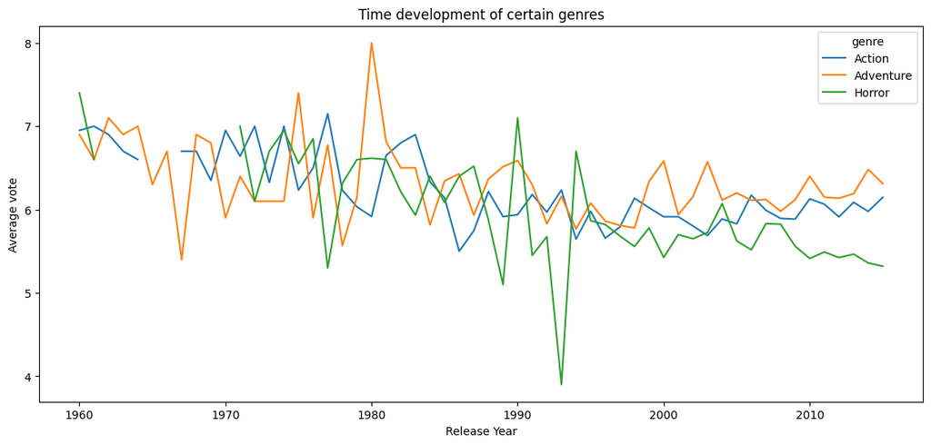

```python
genre_timeplot('Action', 'Adventure', 'Horror')
```

**Takeaway**: From the graph we observe a slight decreasing vote score trend across all three genres from 1960 to 2015. Horror perhaps with the weakest development, spotted with an average the last couple of years below 6 in vote score. We also spot some outliers such as for adventure with a point-spike in '80/'81 and horror with a point-drop in '93/'94. This could be a result of a good(bad) year, or also few movies in our dataframe for those years, with a specially high(low) score.

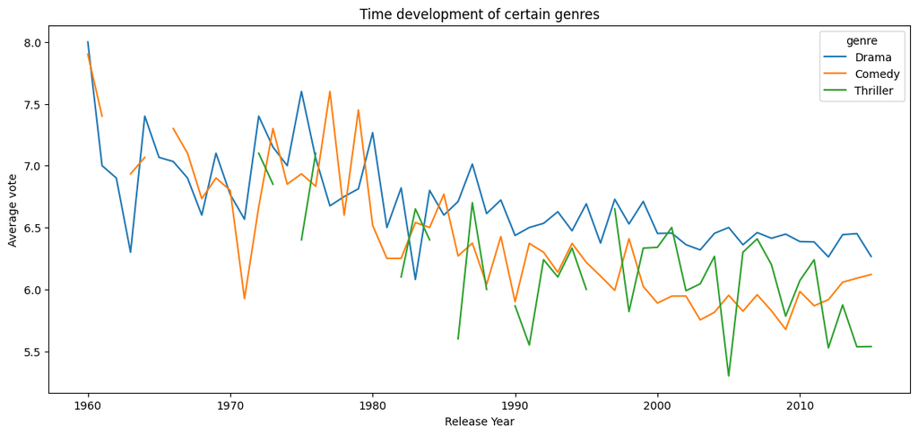

```python
genre_timeplot('Drama', 'Comedy', 'Thriller')
```

**Takeaway**: We spot the same decreasing trend here for all three genres, but perhaps even stronger than for the previous three. Drama had an exceptional year score-wise in 1960, and also seems to score quite well before the 80s. Same development can be seen for the comedy genre, though with some spikes here and there, such as for ~1972 with a bad year score-wise. The thriller genre had only pockets of data prior to the mid 80s, but then with more data continued on a similar trend as the other too, but performing worse than drama almost every year.

## Research Question 2 - Does it matter for the rating who is directing the movie and who the protagonist is?

We will start by looking at data quality for directors and protagonists, then continue choosing the direction of our analysis.

```python
print("Unique directors:", df.director.nunique(),
      " Unique protagonists:", df.protagonist.nunique(),
      " Dataframe length:", len(df))
```

```
Unique directors: 2313  Unique protagonists: 1989  Dataframe length: 5323
```

```python
df.director.value_counts().head(n=5)
```

```
Woody Allen         38
Steven Spielberg    28
Clint Eastwood      27
Ridley Scott        21
Ron Howard          19
Name: director, dtype: int64
```

```python
df.protagonist.value_counts().head(n=5)
```

```
Nicolas Cage      42
Bruce Willis      38
Robert De Niro    36
Johnny Depp       34
Tom Hanks         34
Name: protagonist, dtype: int64
```

*Key Note*: We would prefer having more directors directing many movies (fewer unique directors), the same with protagonists, but this gives us an impression of the data we are working with.

```python
df[['protagonist', 'director']].value_counts().head(n=5)
```

```
protagonist         director
Woody Allen         Woody Allen           22
Clint Eastwood      Clint Eastwood        15
Adam Sandler        Dennis Dugan           7
Johnny Depp         Tim Burton             7
Sylvester Stallone  Sylvester Stallone     6
dtype: int64
```

Certain directors are protagonists in their own movie. This is something we can have a look at as well. First we will have a closer look at the director data.

```python
def dir_data(df):
    '''Function which takes as input a dataframe and
    returns a bar chart with average vote for top & bottom 10 directors
    The data is filtered on directors having directed more than 5 movies'''

    director_votes = pd.DataFrame(df.groupby('director')['vote_average'].mean()).reset_index()
    director_df = pd.DataFrame(df.director.value_counts().reset_index())
    director_df = director_df.rename(columns = {'index': 'director', 'director': 'moviecount'})
    director_df = director_df.merge(director_votes, how= 'inner', on ='director')
    director_df.query('moviecount > 5', inplace=True)
    top10d = director_df.sort_values('vote_average', ascending=False).head(n=10)
    bot10d = director_df.sort_values('vote_average', ascending=False).tail(n=10)
    bot10d = director_df.sort_values('vote_average', ascending=True).head(n=10)
    combined = pd.concat([top10d, bot10d]).sort_values(by='vote_average', ascending=False)
    combined = combined.set_index('director')

    combined.plot(kind='bar'
              , y='vote_average'
             , ylabel='Average Rate'
             , ylim=[3,9]
             , figsize = [14,5]
             , legend = 'yes'
             , rot = 60
                 )
```

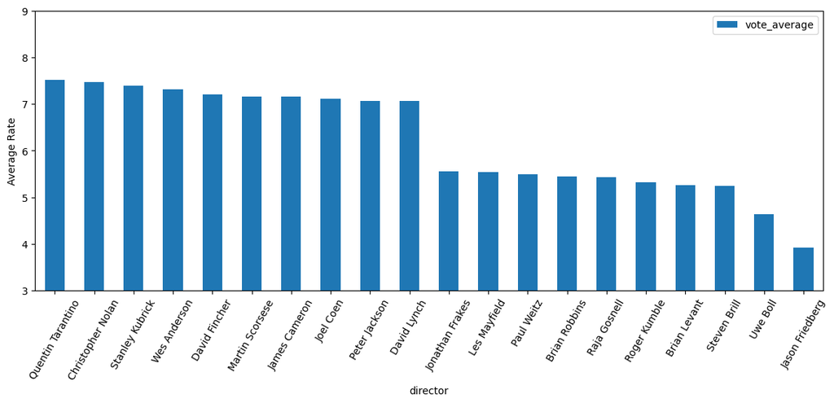

```python
dir_data(df)
```

When we inspect the graph it gives us an impression of what the best and worst directors can achieve in terms of average vote scores across their directed movies. While the famous director Quentin Tarantino with his signature style movies have received an average score of ~7.5, Jason Friedberg on the other hand have an average of ~3.9. This definitely does not seem like a coincidence, but statistical inference will be outside the scope for this analysis.

### Protagonists directing their own movies

Next we will have a look at the phenomenon where the protagonist is also the director of the movie. We will create one population where this is the case, and the other where it isnt, and compare the populations. Again, our main variable of interest will be the average vote score. Are the directors(protagonists) outcompeting movies where this isnt the case? Let's have a look.

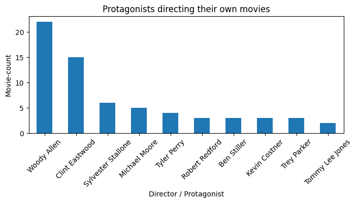

```python
test = df.query('director == protagonist')
test.groupby('director').size().sort_values(ascending=False).head(n=10).plot(
    kind = 'bar'
    , title = 'Protagonists directing their own movies'
    , rot = 45
    , ylabel='Movie-count'
    , xlabel='Director / Protagonist'
    , figsize = [8,3]);
```

We start off by inspecting the data. Clint Eastwood and Sylvester Stallone are famous for producing their own signature style movies. In both cases they are protagonists in their own movies. Next we will have a look at some statistical comparisons between the populations.

```python
def plot_comparison(df):
    '''Takes as input a dataframe and returns two dataframes to
    compute two histograms and two scatterplots, one for each population'''

    dirprot = df.query('director == protagonist')
    dirnprot = df.query('director != protagonist')
    fig, axes = plt.subplots(nrows=2, ncols=2, figsize=(14,10))
    dirprot.plot(kind = 'hist', y='vote_average', ax=axes[0,0], title='Director == Protagonist')
    dirprot.plot(kind = 'scatter', x='release_year', y='vote_average', ax=axes[1,0], title='Director == Protagonist')
    dirnprot.plot(kind = 'hist', y='vote_average', ax=axes[0,1], title='Director != Protagonist')
    dirnprot.plot(kind = 'scatter', x='release_year', y='vote_average', ax=axes[1,1], title='Director != Protagonist')
    plt.show()
```

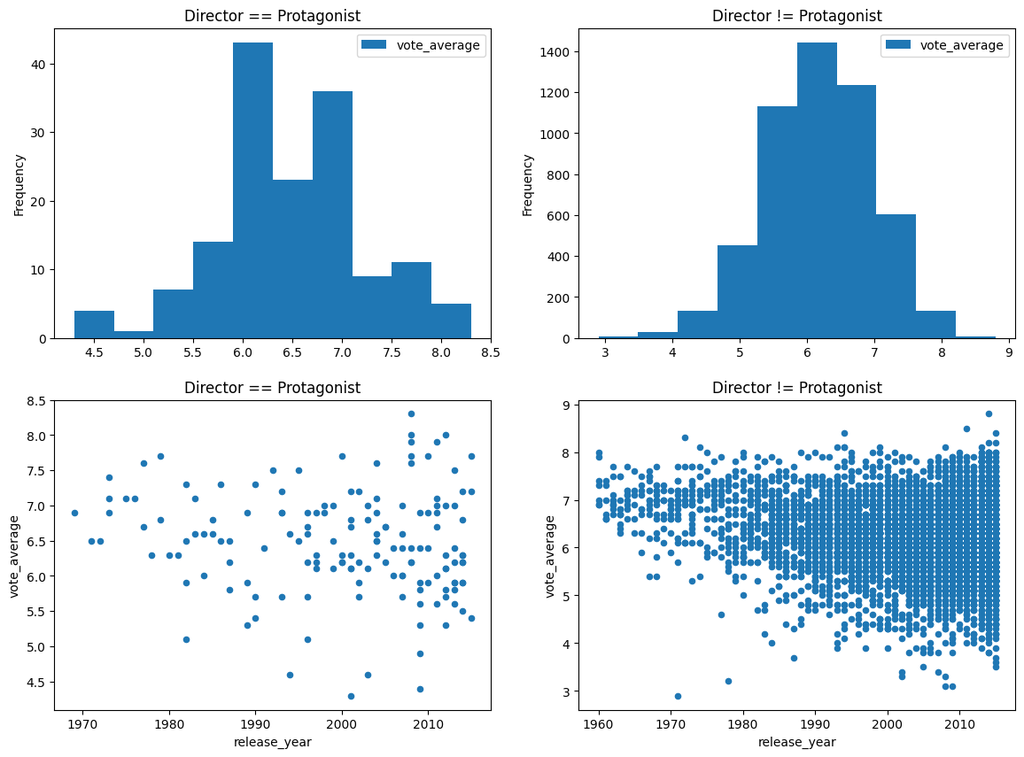

```python
plot_comparison(df)
```

The histograms for both populations look similar, but the director==protagonist sample has fewer score-observations in the range ~6.3 to ~6.8. The sample also doesn't contain any scores below ~4.2. When it comes to the scatterplots, we first of all see fewer datapoints for the leftern plot which is to be expected, but we also spot something else. There seems to be a spike in director==protagonist movie productions from around 2008 and onwards. Score-wise these are all across the scale, but there is an impressive amount with a score > 7 in regards to the sample size. For the director != protagonist sample, data points are widely distributed, but one thing of note is that there were very few bad scores in the 60s and 70s. Let's have a look at a timeseries next.

```python
def prot_timeseries(df):
    '''Takes as input a dataframe and returns a timeseries plot
    with a timeseries for each population with the mean score per year'''

    dirprot = df.query('director == protagonist')
    dirnprot = df.query('director != protagonist')
    dirprot = pd.DataFrame(dirprot.groupby('release_year')['vote_average'].mean(numeric_only=True))
    dirnprot = pd.DataFrame(dirnprot.groupby('release_year')['vote_average'].mean(numeric_only=True))
    dircomb = dirnprot.merge(dirprot, how='left', on='release_year')
    dircomb = dircomb.rename(columns={'vote_average_x': 'Director != Protagonist', 'vote_average_y': 'Director == Protagonist'})

    dircomb.plot(kind='line'
                , figsize=[14,6]
                , title = 'Timeseries comparison of directors and protagonists'
                , xlabel = 'Release Year'
                , ylabel = 'Average Rating')
```

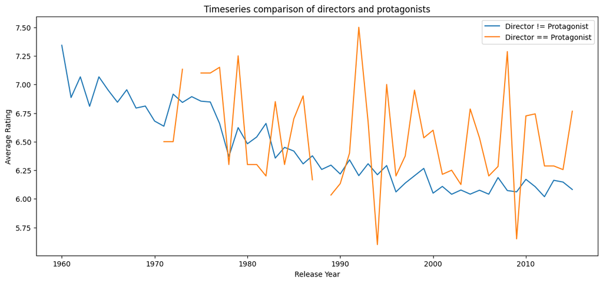

```python
prot_timeseries(df)
```

Finally, we are comparing the development over time for these two samples. For the director==protagonist sample we have to keep in mind the sample size and thus the spikes between the years, but it still does give us an impression of the time-development of these movies. For the director!=protagonist sample we spot a negative trend from the 60s until today for the mean score, as was generally seen for the genres. From 1995 and onwards this sample seems to underperform in terms of score against the director==protagonist sample, except for the year of '08/'09.

## Conclusions

*In this section we will revisit our research questions.*

**How does genres relate to ratings? Are certain genres generally rated better?** In our early exploratory analysis we observed vote distributions from 2.9 all the way up to 9. Some genres had a score centered in a smaller range, while others were quite spread out. From the descriptive statistics we found that the documentary genre was heavily outperforming other genres, while the horror genre was underperforming. Given the large sample we are working with, the sample average was something we could use to draw insights. However, this does not mean that any new observation falls within the score ranges for the genres. From the horror genre, there are also edge cases of very good movies. The documentary genre also had a minimum of 5.3, hence any genre can perform good or bad. That said, certain genres will statistically speaking, more often than not get a good rate. How this translates into the global population of movies is not possible to conclude from this analysis.

**Limitations**: We stuck with data wrangling, exploratory data analysis and descriptive statistics in this report. It would be interesting to extend this analysis to inferential statistics or machine learning concepts to draw more insightful conclusions. Inferential statistics could include confidence intervals, hypothesis testing or regression analysis of scores. Statistical budget-score-revenue matching could also be of interest, and how adjusting one influences the other. Machine learning concepts could also be interesting, such as predicting the average score (y), based on features in the dataframe. Such machine learning can in practice be used to predict movie scores prior to releases. Perhaps even influence choice of directors or actors, or cast in general, as the production team is aiming for a good score. From a movie production point of view, perhaps budget and revenue would be of even higher importance, predicting revenue based on features in the dataframe. In a hypothetical scenario, you can extend this to an optimization problem, where you want to maximize the revenue (or profit) based on the other features.

```python
# Running this cell will execute a bash command to convert this notebook to an .html file
!python -m nbconvert --to html Investigate_a_Dataset.ipynb
```

```
[NbConvertApp] Converting notebook Investigate_a_Dataset.ipynb to html
[NbConvertApp] Writing 1619230 bytes to Investigate_a_Dataset.html
```